# Praca domowa 2

Liwia Jankowska

## Dane

Dane wykorzystane w Pracy domowej 2 opisują wycenę nieruchmości. Każda obserwacja jest pewną nieruchmością, która posiada informacje takie jak powierzchnia, liczba pokoi, liczba łazienek i wiele więcj. Opis wszystkich kolumn w pliku `README.md`.

## Zadanie 1

Jak wygląda rozkład ceny nieruchomości w poszczególnych kodach pocztowych na przestrzeni lat? Rozważamy kody pocztowe, które mają więcej niż 280 posiadłości.

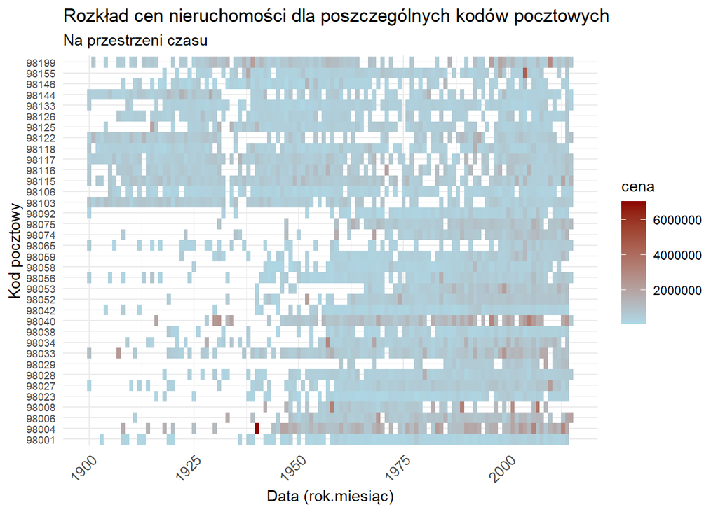

```r
options(scipen = 999)

df_1 <- df %>%
  mutate(zipcode = as.factor(zipcode))

# Wybranie tylko często pojawiających sie kodów
filtered_data <- df_1 %>%
  group_by(zipcode) %>%
  filter(n() > 280) %>%
  ungroup()

# Tworzenie wykresu tile
p <- filtered_data %>%
  ggplot(aes(x = yr_built, y = zipcode, fill = price)) +
  geom_tile() +
  theme_minimal() +
  theme(
    axis.text.x = element_text(angle = 45, hjust = 1, size = 10),
    axis.text.y = element_text(size = 7)# Przechylenie etykiet na osi X
  ) +
  labs(
    title = "Rozkład cen nieruchomości dla poszczególnych kodów pocztowych",
    subtitle = "Na przestrzeni czasu",
    x = "Data (rok.miesiąc)",
    y = "Kod pocztowy",
    fill = "cena"
  ) +
  scale_fill_gradient(low = "lightblue", high = "darkred", na.value = "white")

p
```

**Komentarz: W większości lokalizacji ceny nowszych nieruchomości są delikatnie wyższe niż ceny starszych**

## Zadanie 2

Czy jest różnica w rozkładzie ceny nierchomości od powierzchni mieszkalnej uwzględniając podział na nieruchomości z piwnicą i bez?

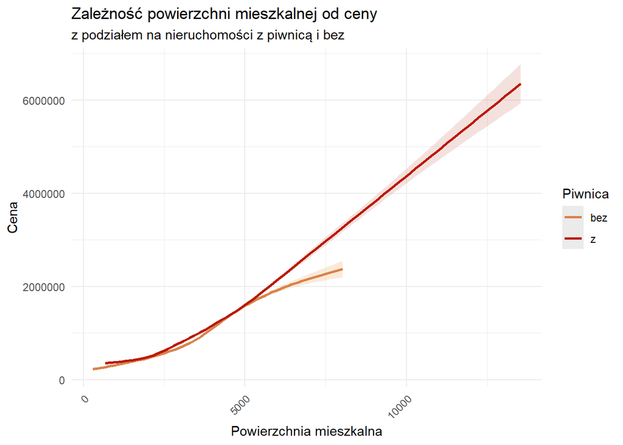

```r
options(scipen = 999)

df_2 <- df %>%
  mutate(basement = if_else(sqft_basement == 0, "bez", "z")) %>%
  mutate(basement = as.factor(basement))

# Zależność powierzchni mieszkalnej od ceny z podziałem na nieruchomości z i bez piwnicy
p <- df_2 %>%
  ggplot(aes(x = sqft_living, y = price, colour = basement, fill = basement)) +
  geom_smooth(se = TRUE, alpha = 0.2) +  # Zastosowanie geom_smooth() dla wygładzania linii
  theme_minimal() +
  theme(
    axis.text.x = element_text(angle = 45, hjust = 1),  # Przechylenie etykiet na osi X
  ) +
  labs(
    title = "Zależność powierzchni mieszkalnej od ceny",
    subtitle = "z podziałem na nieruchomości z piwnicą i bez",
    x = "Powierzchnia mieszkalna",
    y = "Cena",
    colour = "Piwnica"
  ) +
  guides(fill = "none") +
  scale_colour_manual(values = c("z" = "#bb1900","bez" = "#d9824b")) + # Kolorowanie linii
  scale_fill_manual(values = c("z" = "#c96b5b","bez" = "#e9983b")) # Kolorowanie wypełnienia

p
```

**Komentarz: Od pewniej powierzchni mieszkalnej nieruchomości bez piwnicy zaczynają byc tańszę a później nie wystepują, dla dostatecznie małej powierzchni dostępne są tylko nieruchomości bez piwnicy**

## Zadanie 3

Jaka jest zależność pomiędzy jakością wykończenia nieruchomości a liczbą pięter?

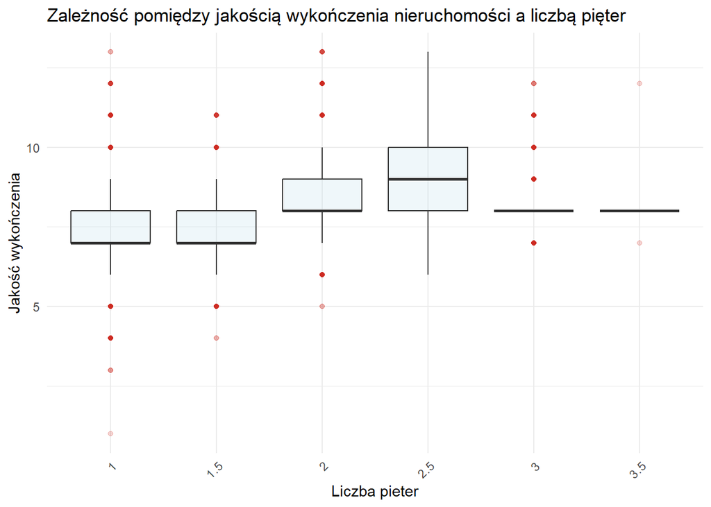

```r
options(scipen = 999)

p <- df %>%
  ggplot(aes(x = as.factor(floors), y = grade)) +
  geom_boxplot(alpha = 0.2, outlier.colour = "#cb2920", fill = "lightblue") +
  theme_minimal() +
  theme(
    axis.text.x = element_text(angle = 45, hjust = 1),  # Przechylenie etykiet na osi X
  ) +
  labs(
    title = "Zależność pomiędzy jakością wykończenia nieruchomości a liczbą pięter",
    x = "Liczba pieter",
    y = "Jakość wykończenia"
  )

p
```

## Zadanie 4

Jaka jest zależność między powierzchnią mieszkalną nieruchomości a powierzchnią gruntu w podziale na liczbę sypialni?

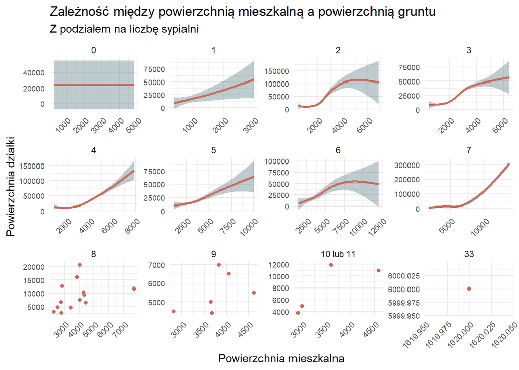

```r
options(scipen = 999)

# Zależność powierzchni mieszkalnej od powierzchni działki z podziałem na liczbe sypialni
df_3 <- df %>%
  mutate(bedrooms = case_when(bedrooms == 10 ~ "10 lub 11",
                              bedrooms == 11 ~ "10 lub 11",
                              TRUE ~ as.character(bedrooms)),
         bedrooms = factor(bedrooms, levels = c("0", "1", "2", "3", "4", "5", "6", "7", "8", "9", "10 lub 11", "33")))

p <- df_3 %>%
  ggplot() +
  geom_smooth(data = filter(df_3, bedrooms %in% c("0", "1", "2", "3", "4", "5", "6", "7")),
              color = "#c96b5b", fill = "#5E8088", aes(x = sqft_living, y = sqft_lot)) +
  geom_point(data = filter(df_3, bedrooms %in% c("8", "9", "10 lub 11", "33")),
             color = "#c96b5b", aes(x = sqft_living, y = sqft_lot)) + # Oddzielne rodzaj wykresów dla mniejszej i większej ilości obserwacji
  theme_minimal() +
  theme(
    axis.text.x = element_text(angle = 45, hjust = 1, size = 8),
    axis.text.y = element_text(size = 7) # Przechylenie etykiet na osi X
  ) +
  labs(
    title = "Zależność między powierzchnią mieszkalną a powierzchnią gruntu",
    subtitle = "Z podziałem na liczbę sypialni",
    x = "Powierzchnia mieszkalna",
    y = "Powierzchnia działki"
  ) +
  facet_wrap(~bedrooms, scales = "free")

p
```

**Komentarz: Powierzchnia mieszkalna jest tym większa im większa jest działka**

## Zadanie 5

Rozważmy tylko nieruchomości, które miały remont. W której dekadzie było najwięcej przeprowadzonych remontów? Czy w poszczególnych dekadach jest porównywalny procent nieruchmości dla każdej wartości miary jakości i wykończenia nieruchomości?

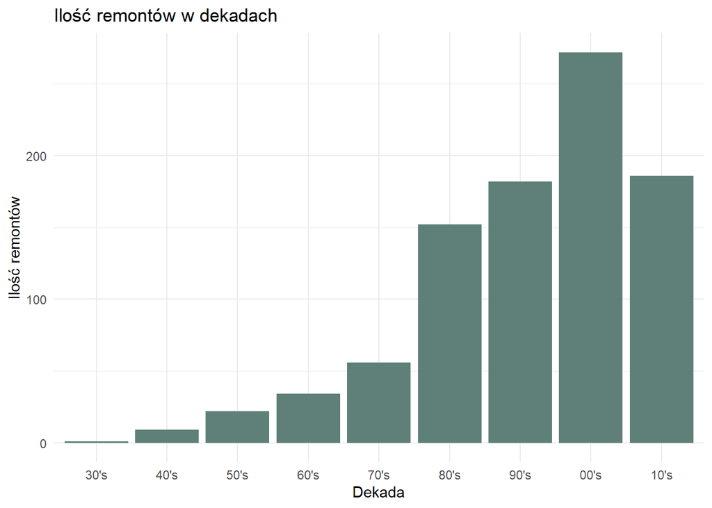

```r
options(scipen = 999)

df_5.1 <- df %>%
  filter(yr_renovated != 0) %>%
  mutate(d_renovated = substr(as.character(yr_renovated), 3, 3)) %>%
  mutate(d_renovated = paste0(d_renovated, "0's"), # dodawanie kolumny z dekadą remontu
         d_renovated = factor(d_renovated, levels =
                                c("30's", "40's", "50's", "60's", "70's", "80's", "90's", "00's", "10's")))

df_5.2 <- df %>%
  mutate(d_built = paste0(substr(yr_built, 3, 3), "0's"), # dodawanie kolumny z dekadą zbudowania
         d_built = factor(d_built, levels =
                            c("20's", "30's", "40's", "50's", "60's", "70's", "80's", "90's", "00's", "10's"))) %>%
  group_by(d_built, grade, condition) %>%
  mutate(count = n()) %>%
  ungroup %>%
  select(c(grade, d_built, count)) %>%
  group_by(grade) %>%
  mutate(percent = count * 100 / n()) %>% # Liczenie procentu
  ungroup %>%
  unique()

# Sprawdzanie
# sum(unique(filter(df_5.2, grade == 3))$percent)

# Ilość remontów w dekadach
p1 <- df_5.1 %>%
  ggplot(aes(x = as.factor(d_renovated))) +
  geom_bar(fill = "#5E8078") +
  labs(
    title = "Ilość remontów w dekadach",
    x = "Dekada",
    y = "Ilość remontów"
  ) +
  theme_minimal()


# Ilość nieruchomości z poszczególnych dekad z rozdzieleniem na oceny
p2 <- df_5.2 %>%
  ggplot(aes(x = grade, y = percent)) +
  geom_col(fill = "#5E8078") +
  labs(
    title = "procent nieruchomości w poszczególnych dekadach",
    subtitle = "z uwzględnieniem miary jakości i wykończenia",
    x = "dekada od 1920 do 2010",
    y = "procent"
  ) +
  facet_wrap(~ d_built, scales = "free_y") +
  theme_minimal()

p1
```

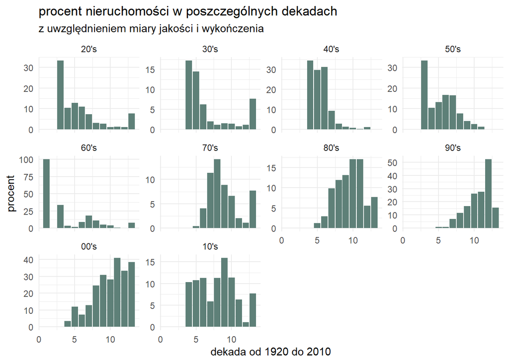

```r
p2
```

**Komentarz: Z pierwszego wykresu wynika, że najwięcej remontów wykonano pomiędzy rokiem 2000 a 2009. Na drugim wykresie widać, że dla każdej dekady, wartości miary wykończenia nieruchomości bardzo się od siebie różnią**

## Zadanie 6

Jak prezentuje się wartość minimalna, średnia i maksymalna ceny nieruchmości w podziele na rok budowy nieruchomości.

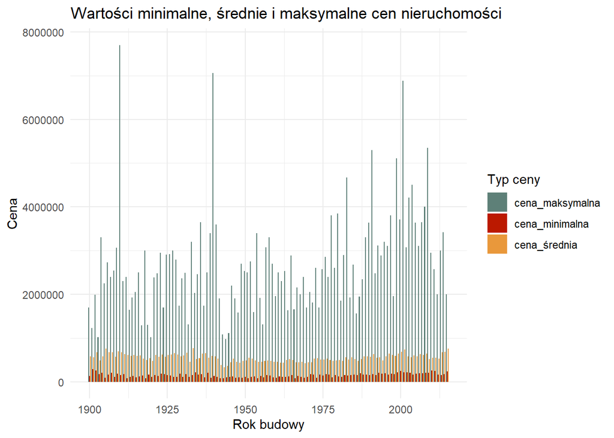

```r
df_6 <- df %>%
  group_by(yr_built) %>%
  summarise(cena_minimalna = min(price),
            cena_średnia = mean(price),
            cena_maksymalna = max(price)) %>%
  ungroup() %>%
  pivot_longer(cols = c(cena_minimalna, cena_średnia, cena_maksymalna),
             names_to = "price_type",
             values_to = "price_value")


p <- df_6 %>%
  ggplot(aes(x = yr_built, y = price_value, fill = price_type)) +
  geom_col(position = "dodge") +  # Użycie dodge dla oddzielnych słupków
  labs(
    title = "Wartości minimalne, średnie i maksymalne cen nieruchomości",
    x = "Rok budowy",
    y = "Cena",
    fill = "Typ ceny"
  ) +
  theme_minimal() +
  scale_fill_manual(values = c("cena_minimalna" = "#bb1900","cena_średnia" = "#e9983b", "cena_maksymalna" = "#5E8078")) # Kolorowanie wypełnienia

p
```

**Komentarz: Cena maksymalna ma dużo większe wachania na przestrzeni czasu niż cena minimalna i średnia**